# Statistical mathematics project work

## Pouya Amiri

### 001144253

#### Task 1

**1. Describe in a few words what is the binomial distribution and what are its parameters and their meaning.**

a Binomial distribution happens when you do $n$ mutually independent experiments. Each of these experiments have the probability of $p$, and we denote the success of each experiment with $1$, and their failiure with $0$. Notation: $X$ ~ $(n, p)$

**2. Plot the binomial distribution with p = 0.7 and size n = 26. Add a suitable title to your plot.**

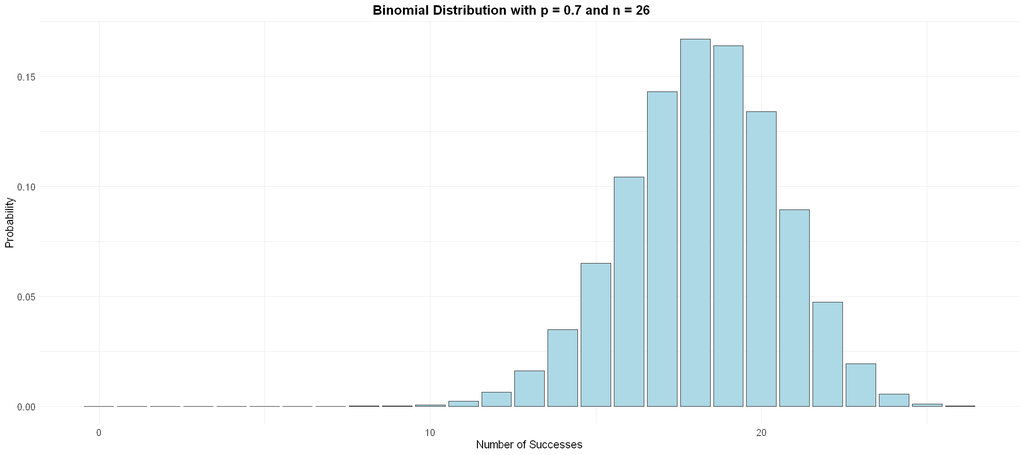

```r
library(ggplot2)

p <- 0.7
n <- 26
x <- 0:n
y <- dbinom(x, size = n, prob = p)

df <- data.frame(x, y)

# Create the bar plot using ggplot2
ggplot(data = df, aes(x = x, y = y)) +
      geom_col(fill = "lightblue", color = "#252525") +
      labs(title = "Binomial Distribution with p = 0.7 and n = 26",
            x = "Number of Successes",
            y = "Probability") +
      theme_minimal() +
      theme(plot.title = element_text(hjust = 0.5, size = 16, face = "bold"),
            axis.text = element_text(size = 12),
            axis.title = element_text(size = 14),
            plot.title.position = "plot")

options(repr.plot.width = 18, repr.plot.height = 8)
```

#### Task 2

**1. Describe in a few words what is the Poisson distribution and what are its parameters and their meaning.**

a Poisson distribution is when some **independent** events happen with the average rate of $λ$ per time unit. $X$ is the number of the events. Notation: $X$ ~ $Poisson(λ)$

**2. Plot the Poisson distribution for $λ$ = 7 and $k$ = 0, 1, . . . , 30.**

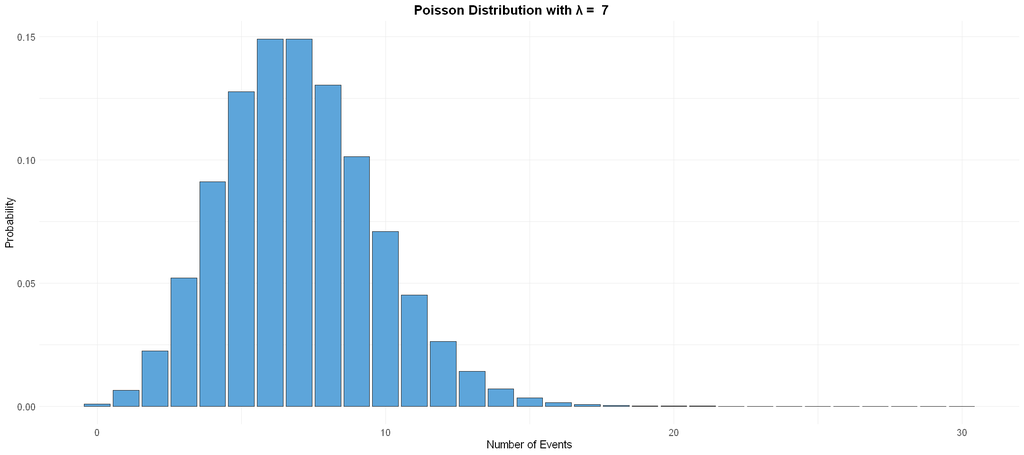

```r
lambda <- 7
k <- 0:30

poisson_df <- data.frame(k = k, poisson_dist = dpois(k, lambda))

ggplot(poisson_df, aes(x = k, y = poisson_dist)) +
     geom_col(fill = "#5DA5DA", color = "#252525") +
     labs(title = paste("Poisson Distribution with λ = ", lambda),
          x = "Number of Events", y = "Probability") +
     theme_minimal() +
     theme(plot.title = element_text(hjust = 0.5, size = 16, face = "bold"),
          axis.text = element_text(size = 12),
          axis.title = element_text(size = 14),
          plot.title.position = "plot")
```

#### Task 3

**1. Describe in a few words what is the normal distribution and what are its parameters and their meaning.**

a Normal distribution (Gaussian distribution) is a continuous probability distribution for a random variable ($X$). It has two parameter: The mean ($μ$) and the standard deviation ($σ$).

Mean is the arithmetic mean or average, and standard deviation shows the spread of data.

**2. Plot the distribution for $μ$ = −3 and $σ$ = 0.4 for $x$ ∈ [−5, −1]**

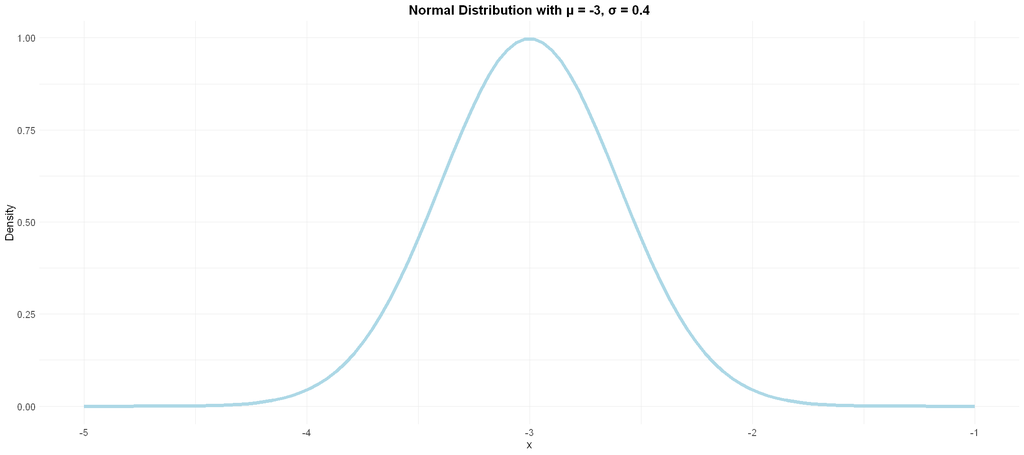

```r
mu <- -3
sigma <- 0.4
x <- seq(-5, -1, length.out = 100)
y <- dnorm(x, mean = mu, sd = sigma)

ggplot(data.frame(x = x, y = y), aes(x, y)) +
    geom_line(color = "lightblue", size = 2) +
    scale_x_continuous(limits = c(-5, -1)) +
    labs(title = "Normal Distribution with μ = -3, σ = 0.4", x = "x", y = "Density") +
    theme_minimal() +
    theme(plot.title = element_text(hjust = 0.5, size = 16, face = "bold"),
        axis.text = element_text(size = 12),
        axis.title = element_text(size = 14))
```

#### Task 4

**Study the dataset data-set-1.csv.**

**1. There is only one column, what is its name?**

```r
dataset1 <- read.csv("data-set-1.csv")

columnName <- colnames(dataset1)

print(paste("Column Name: ", columnName))
```

```
[1] "Column Name:  Ratio"
```

**2. How many rows are there?**

```r
rowCount <- nrow(dataset1)

print(paste("Number of rows: ", rowCount))
```

```
[1] "Number of rows:  250"
```

The function "read.csv" assumes the first row is the header, so it gets excluded from the count. There are 251 with the header, and 250 without it.

**3. What is the minimum value of the dataset?**

```r
minVal = min(dataset1)

print(paste("Minimum value: ", minVal))
```

```
[1] "Minimum value:  0.0122069101012438"
```

**4. What is the maximal value?**

```r
maxVal = max(dataset1)

print(paste("Maximum value: ", maxVal))
```

```
[1] "Maximum value:  0.897346195930063"
```

**5. What is the mean?**

```r
meanVal = mean(dataset1$"Ratio")

print(paste("Mean value: ", meanVal))
```

```
[1] "Mean value:  0.405735528587853"
```

**6. What is the median?**

```r
medianVal = median(dataset1$"Ratio")

print(paste("Median value: ", medianVal))
```

```
[1] "Median value:  0.394038280207475"
```

**7. What is the unbiased sample variance?**

```r
varVal = var(dataset1$"Ratio")

print(paste("Variance value: ", varVal))
```

```
[1] "Variance value:  0.0366762627795037"
```

**8. Plot a histogram of 9 evenly spaced bins of the data.**

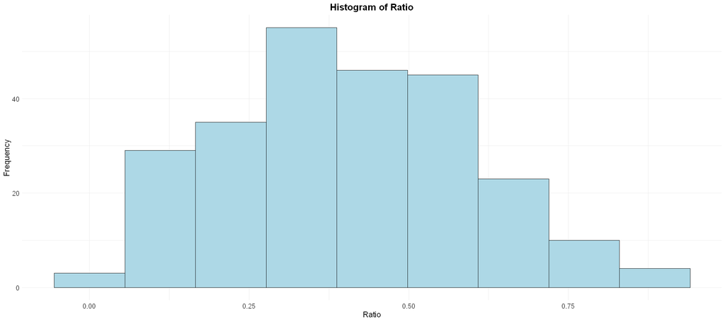

```r
ggplot(data = dataset1, aes(x = Ratio)) +
    geom_histogram(bins = 9, color = "black", fill = "lightblue") +
    labs(title = "Histogram of Ratio", x = "Ratio", y = "Frequency") +
    theme_minimal() +
    theme(plot.title = element_text(hjust = 0.5, size = 16, face = "bold"),
        axis.text = element_text(size = 12),
        axis.title = element_text(size = 14))
```

#### Task 5

**A box has 10 coins: six fair ones (prob. of a heads θ = 0.5), two unfair ones (θ = 0.25 and θ = 0.75) and two magical cheating coins (θ = 0 and θ = 1). They all look and feel the same. A coin is taken randomly from the box, and its type Θ has the distribution**

| θ | 0 | 0.25 | 0.5 | 0.75 | 1 |
| --- | --- | --- | --- | --- | --- |
| P(Θ = θ) | 0.1 | 0.1 | 0.6 | 0.1 | 0.1 |

**Recall the law of total probability and Bayes’ rule and solve the following problems:**

**1. What is the probability of flipping a heads with the unknown coin?**

P(H) = P(H | θ = 0)P(θ = 0) + P(H | θ = 0.25)P(θ = 0.25) + P(H | θ = 0.5)P(θ = 0.5) + P(H | θ = 0.75)P(θ = 0.75) + P(H | θ = 1)P(θ = 1) = (0 * 0.1) + (0.25 * 0.1) + (0.5 * 0.6) + (0.75 * 0.1) + (1 * 0.1) = 0.5

$$OR$$

```r
Type <- c(0, 0.25, 0.5, 0.75, 1)
Probability <- c(0.1, 0.1, 0.6, 0.1, 0.1)

headProbability <- sum(Probability * Type)

print(paste("Probability of flipping a head: ", headProbability))
```

```
[1] "Probability of flipping a head:  0.5"
```

**2. You flip the coin and get heads. Call this event H. Conditioned on H, what is the probability that the coin has Θ = 0.25?**

P(Θ = 0.25 | H) = P(H | Θ = 0.25) * P(Θ = 0.25) / P(H) = 0.25 * 0.1 / 0.5 = 0.05

$$OR$$

```r
result = 0.25 * Probability[which(Type == 0.25)] / headProbability

print(paste("Probability of Θ = 0.25 given that the flip was a head: ", result))
```

```
[1] "Probability of Θ = 0.25 given that the flip was a head:  0.05"
```

**3. Calculate the “posterior probabilities” of P (Θ = θ | H) for θ ∈ {0, 0.25, 0.5, 0.75, 1}. The case θ = 0.25 was solved in item 2.**

```r
results <- list()  # create an empty list to store the results

for (i in 1:length(Type)) {
    x <- Type[i]
    result <- x * Probability[which(Type == x)] / headProbability
    results[[i]] <- result
    names(results)[[i]] <- as.character(x)  # convert numeric value to character for naming
    message(sprintf("Probability of Θ = %s given that the flip was a head:  %s", x, result))
}
```

[output not shown]

**4. Plot a bar chart of the prior distribution P (Θ = θ) and of the posterior distribution P (Θ = θ | H).**

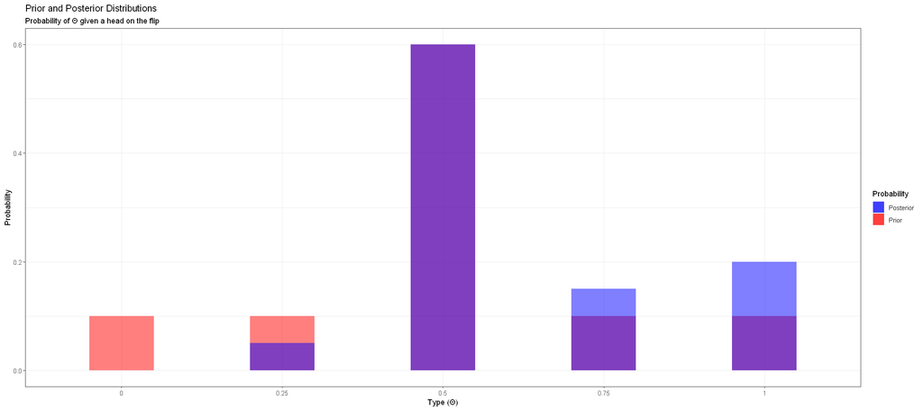

```r
# create a data frame for plotting
df <- data.frame(Type = as.character(Type),
                 Probability = Probability,
                 Posterior_Prob = unlist(results))

# plot using ggplot
ggplot(df, aes(x = Type, y = Probability, fill = "Prior")) +
  geom_bar(stat = "identity", alpha = 0.5, width = 0.4) +
  geom_bar(aes(y = Posterior_Prob, fill = "Posterior"), stat = "identity", alpha = 0.5, width = 0.4) +
  scale_fill_manual(name = "Probability", values = c("blue", "red")) +
  labs(title = "Prior and Posterior Distributions",
       subtitle = "Probability of Θ given a head on the flip",
       x = "Type (Θ)", y = "Probability") +
  theme_bw()
```

#### Task 6

**Use the dataset data-set-2.csv. Using the Pearson correlation coefficient (cor in R, or correl in Excel) find four other variables which are most correlated with horsepower (hp). In other words, compute the correlation coefficient of the other variable with respect to hp. Select those which have the biggest absolute value of the correlation.**

| Variable | Explanation |
| --- | --- |
| mpg | Miles/(US) gallon |
| cyl | Number of cylinders |
| disp | Displacement (cu.in.) |
| hp | Gross horsepower |
| drat | Rear axle ratio |
| wt | Weight (1000 lbs) |
| qsec | 1/4 mile time |
| vs | Engine (0 = V-shaped, 1 = straight) |
| am | Transmission (0 = automatic, 1 = manual) |
| gear | Number of forward gears |
| carb | Number of carburetors |

```r
dataset2 <- read.csv("data-set-2.csv")

correlation <- cor(dataset2[, -1])
correlation
```

A matrix: 11 × 11 of type dbl

|  | mpg | cyl | disp | hp | drat | wt | qsec | vs | am | gear | carb |
| --- | --- | --- | --- | --- | --- | --- | --- | --- | --- | --- | --- |
| mpg | 1.0000000 | -0.8521620 | -0.8475514 | -0.7761684 | 0.68117191 | -0.8676594 | 0.41868403 | 0.6640389 | 0.59983243 | 0.4802848 | -0.55092507 |
| cyl | -0.8521620 | 1.0000000 | 0.9020329 | 0.8324475 | -0.69993811 | 0.7824958 | -0.59124207 | -0.8108118 | -0.52260705 | -0.4926866 | 0.52698829 |
| disp | -0.8475514 | 0.9020329 | 1.0000000 | 0.7909486 | -0.71021393 | 0.8879799 | -0.43369788 | -0.7104159 | -0.59122704 | -0.5555692 | 0.39497686 |
| hp | -0.7761684 | 0.8324475 | 0.7909486 | 1.0000000 | -0.44875912 | 0.6587479 | -0.70822339 | -0.7230967 | -0.24320426 | -0.1257043 | 0.74981247 |
| drat | 0.6811719 | -0.6999381 | -0.7102139 | -0.4487591 | 1.00000000 | -0.7124406 | 0.09120476 | 0.4402785 | 0.71271113 | 0.6996101 | -0.09078980 |
| wt | -0.8676594 | 0.7824958 | 0.8879799 | 0.6587479 | -0.71244065 | 1.0000000 | -0.17471588 | -0.5549157 | -0.69249526 | -0.5832870 | 0.42760594 |
| qsec | 0.4186840 | -0.5912421 | -0.4336979 | -0.7082234 | 0.09120476 | -0.1747159 | 1.00000000 | 0.7445354 | -0.22986086 | -0.2126822 | -0.65624923 |
| vs | 0.6640389 | -0.8108118 | -0.7104159 | -0.7230967 | 0.44027846 | -0.5549157 | 0.74453544 | 1.0000000 | 0.16834512 | 0.2060233 | -0.56960714 |
| am | 0.5998324 | -0.5226070 | -0.5912270 | -0.2432043 | 0.71271113 | -0.6924953 | -0.22986086 | 0.1683451 | 1.00000000 | 0.7940588 | 0.05753435 |
| gear | 0.4802848 | -0.4926866 | -0.5555692 | -0.1257043 | 0.69961013 | -0.5832870 | -0.21268223 | 0.2060233 | 0.79405876 | 1.0000000 | 0.27407284 |
| carb | -0.5509251 | 0.5269883 | 0.3949769 | 0.7498125 | -0.09078980 | 0.4276059 | -0.65624923 | -0.5696071 | 0.05753435 | 0.2740728 | 1.00000000 |

```r
hpCor <- abs(correlation[, "hp"])
hpCorSort <- sort(hpCor, decreasing = TRUE)
hpCorSort
```

**hp**

1

**cyl**

0.83244745272182

**disp**

0.790948586369806

**mpg**

0.776168371826586

**carb**

0.74981247154911

**vs**

0.72309673735245

**qsec**

0.708223388861953

**wt**

0.658747887344759

**drat**

0.44875911687292

**am**

0.243204257185851

**gear**

0.125704258225474

```r
hpTopCor <- names(hpCorSort)[2:5]

cat(sprintf("Top 4 variables that most correlated with horsepower:\n\n"))
for (var in hpTopCor) {
  corr <- cor(dataset2[[var]], dataset2$hp)
  cat(sprintf("%-10s:  %f\n", var, corr))
}
```

[output not shown]

#### Task 7

**1. A company says that the higher price a part has, the longer it will be before needing to be repaired (MTBR). Analyse the columns Part price and MTBR and say whether the company is correct. You must explain your answer using statistical tools and graphs.**

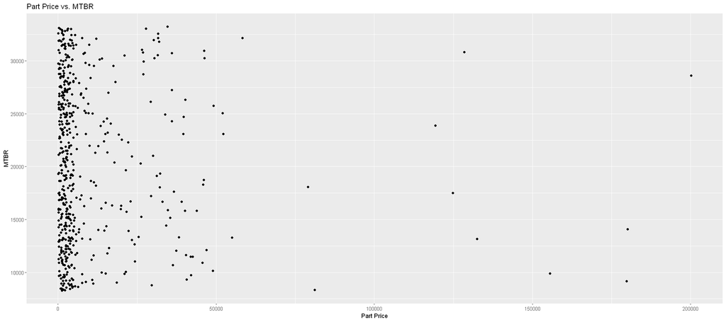

```r
dataset3 <- read.csv("data-set-3.csv")

ggplot(data=dataset3, aes(x=Part.Price, y=MTBR)) +
  geom_point() +
  labs(x="Part Price", y="MTBR", title="Part Price vs. MTBR")
```

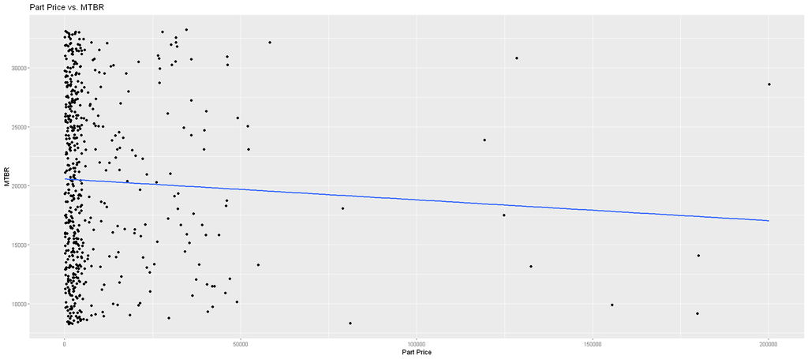

```r
model <- lm(MTBR ~ Part.Price, data = dataset3)

ggplot(dataset3, aes(x = Part.Price, y = MTBR)) +
  geom_point() +
  geom_smooth(method = "lm", se = FALSE) +
  labs(x="Part Price", y="MTBR", title="Part Price vs. MTBR")
```

So, it seems the claim is **not** true. Since the line slopes downward from left to right, it means that as the price increases, MTBR decreases.

**2. Find a simple approximate linear formula for Part price based on the variables Part cost and Repair labor cost. Based on statistics of linear regression, how good is the approximation? (Hint: lm() in R and Regression in Excel’s Data Analysis toolpak can handle linear models of the form y = ax1 + bx2 + c. Search online how to fit that model if you don’t know.)**

```r
model <- lm(Part.Price ~ Part.Cost + Repair.labor.Cost, dataset3)

# Print the model summary
summary(model)
```

```
Call:
lm(formula = Part.Price ~ Part.Cost + Repair.labor.Cost, data = dataset3)

Residuals:
     Min       1Q   Median       3Q      Max
-26925.0   -323.0    267.7    680.9  30173.6

Coefficients:
                    Estimate Std. Error t value Pr(>|t|)
(Intercept)       -338.52300  185.80481  -1.822  0.06902 .
Part.Cost            1.38458    0.06021  22.996  < 2e-16 ***
Repair.labor.Cost    0.47287    0.15533   3.044  0.00245 **
---
Signif. codes:  0 '***' 0.001 '**' 0.01 '*' 0.05 '.' 0.1 ' ' 1

Residual standard error: 3880 on 542 degrees of freedom
Multiple R-squared:  0.9676,	Adjusted R-squared:  0.9675
F-statistic:  8093 on 2 and 542 DF,  p-value: < 2.2e-16
```

Part Price = -338.52300 + 1.38458 * Part Cost + 0.47287 * Repair Labor Cost

**Task 8. In this task we will use samples from the population in data-set-4.csv. The population is normally distributed N (μ, σ). The goal of this exercise is to estimate μ and/or σ based on a sample. You will start by creating the samples you will use based on your student ID.**

**1. Write your own student ID instead of 012345678 in the code below. Open RStudio and run the following commands, filling details based on your own situation:**

```r
pop <- read.csv("data-set-4.csv")
set.seed(001144253)
x <- sample(pop[,2], size = 100, replace = T)
y <- sample(pop[,2], size = 15, replace = T)
```

```r
y
```

1. 228.029109978092

2. 153.468848674789

3. 77.3934680986097

4. 270.128077318504

5. 160.242369769152

6. 174.502034382948

7. 225.252427256122

8. 247.458727572961

9. 275.382755328582

10. 185.244483084107

11. 282.962921677414

12. 282.712009509889

13. 241.321056488148

14. 79.112117183707

15. 232.753901072401

**2. If you know that σ = 50, calculate a point estimate for μ and a 95% confidence interval using the small sample y.**

```r
meanY <- mean(y, na.rm = TRUE)

print(paste("Mean of y: ", meanY))
```

```
[1] "Mean of y:  207.730953826362"
```

```r
SD <- 50

errorMarginY <- qt(0.975, df = length(y) - 1) * SD / sqrt(length(y))
print(paste("Margin of error: ", errorMarginY))

confidenceIntervalY <- meanY + c(-1, 1) * qt(0.025, df = length(y) - 1) * (SD / sqrt(length(y)))
print("Confidence Interval: ")
confidenceIntervalY
```

```
[1] "Margin of error:  27.6890770782434"
[1] "Confidence Interval: "
```

1. 235.420030904605

2. 180.041876748118

**3. Assume you don’t know σ in advance. Calculate a point estimate for μ and a 95% confidence interval using the large sample x.**

```r
meanX <- mean(x, na.rm = TRUE)

print(paste("Mean of x: ", meanX))
```

```
[1] "Mean of x:  246.608287864487"
```

```r
errorMarginX <- qt(0.975, df = length(x) - 1) * sd(x) / sqrt(length(x))
print(paste("Margin of error: ", errorMarginX))

confidenceIntervalX <- meanX + c(-1, 1) * qt(0.025, df = length(x) - 1) * (sd(x) / sqrt(length(x)))
print("Confidence Interval: ")
confidenceIntervalX
```

```
[1] "Margin of error:  10.0781345905684"
[1] "Confidence Interval: "
```

1. 256.686422455055

2. 236.530153273919

**4. Same as the previous one, but now use the small sample y instead of x.**

```r
errorMarginY2 <- qt(0.975, df = length(y) - 1) * sd(y) / sqrt(length(y))
print(paste("Margin of error: ", errorMarginY2))

confidenceIntervalY2 <- meanY + c(-1, 1) * qt(0.025, df = length(y) - 1) * (sd(y) / sqrt(length(y)))
print("Confidence Interval: ")
confidenceIntervalY2
```

```
[1] "Margin of error:  37.4845477997317"
[1] "Confidence Interval: "
```

1. 245.215501626093

2. 170.24640602663

**5. It is claimed that the true expected value is supposed to be $μ = 245$. You don’t know σ. Based on the large sample x, would you accept or reject the claim?**

The confidence interval is between 236.5 and 256.6, which means that we are 95% confident that the mean is in that range. $μ = 245$ is in that range, so we cannot reject the claim.